# py_xgboost_multiclass_crop_mapping_optical_radar

### December 28, 2021

Template Credit: Adapted from a template made available by Dr. Jason Brownlee of Machine Learning Mastery. [https://machinelearningmastery.com/]

SUMMARY: This project aims to construct a predictive model using various machine learning algorithms and document the end-to-end steps using a template. The Crop Mapping with Fused Optical Radar Data dataset is a multi-class modeling situation where we attempt to predict one of several (more than two) possible outcomes.

INTRODUCTION: This dataset combines optical and PolSAR remote sensing images for cropland classification. The organization collected the images using RapidEye satellites (optical) and the Unmanned Aerial Vehicle Synthetic Aperture Radar (UAVSAR) system (radar) over an agricultural region near Winnipeg, Manitoba, Canada, in 2012. There are two sets of 49-radar features and two sets of 38-optical features for 05 and 14 July 2012. Seven crop type classes exist for this data set: 1-Corn; 2-Peas; 3-Canola; 4-Soybeans; 5-Oats; 6-Wheat; and 7-Broadleaf.

ANALYSIS: The performance of the preliminary XGBoost model achieved an accuracy benchmark of 0.9977. After a series of tuning trials, the final model processed the training dataset with an accuracy score of 0.9982. When we processed the test dataset with the final model, the model achieved an accuracy score of 0.9982.

CONCLUSION: In this iteration, the XGBoost model appeared to be a suitable algorithm for modeling this dataset.

Dataset Used: Crop Mapping with Fused Optical Radar Data

Dataset ML Model: Multi-class classification with numerical attributes

Dataset Reference: https://archive-beta.ics.uci.edu/ml/datasets/crop+mapping+using+fused+optical+radar+data+set

## Task 1 - Prepare Environment

```python
# Install the necessary packages for Colab
# !pip install python-dotenv PyMySQL
```

```python
# # Retrieve the GPU information from Colab
# gpu_info = !nvidia-smi
# gpu_info = '\n'.join(gpu_info)
# if gpu_info.find('failed') >= 0:
#     print('Select the Runtime → "Change runtime type" menu to enable a GPU accelerator, ')
#     print('and then re-execute this cell.')
# else:
#     print(gpu_info)
```

```python
# # Retrieve the memory configuration from Colab
# from psutil import virtual_memory
# ram_gb = virtual_memory().total / 1e9
# print('Your runtime has {:.1f} gigabytes of available RAM\n'.format(ram_gb))

# if ram_gb < 20:
#     print('To enable a high-RAM runtime, select the Runtime → "Change runtime type"')
#     print('menu, and then select High-RAM in the Runtime shape dropdown. Then, ')
#     print('re-execute this cell.')
# else:
#     print('You are using a high-RAM runtime!')
```

```python
# # Mount Google Drive locally for loading the dotenv files
# from dotenv import load_dotenv
# from google.colab import drive
# drive.mount('/content/gdrive')
# gdrivePrefix = '/content/gdrive/My Drive/Colab_Downloads/'
# env_path = '/content/gdrive/My Drive/Colab Notebooks/'
# dotenv_path = env_path + "python_script.env"
# load_dotenv(dotenv_path=dotenv_path)
```

```python
# Retrieve the CPU information
ncpu = !nproc
print("The number of available CPUs is:", ncpu[0])
```

```
The number of available CPUs is: 8
```

### 1.a) Load libraries and modules

```python
# Set the random seed number for reproducible results
RNG_SEED = 88
```

```python
import numpy as np
import pandas as pd
import seaborn as sns
import matplotlib.pyplot as plt
import os
import sys
import math
# import boto3
from datetime import datetime
from sklearn import preprocessing
from sklearn.model_selection import train_test_split
from sklearn.model_selection import StratifiedKFold
from sklearn.model_selection import cross_val_score
from sklearn.model_selection import GridSearchCV
from sklearn.metrics import classification_report
from sklearn.metrics import confusion_matrix
from sklearn.metrics import accuracy_score
from sklearn.pipeline import Pipeline
from sklearn import compose
from sklearn import impute

# from sklearn.feature_selection import RFE
# from imblearn.pipeline import Pipeline
# from imblearn.over_sampling import SMOTE
# from imblearn.under_sampling import RandomUnderSampler

from xgboost import XGBClassifier
```

### 1.b) Set up the controlling parameters and functions

```python
# Begin the timer for the script processing
START_TIME_SCRIPT = datetime.now()

# Set up the number of CPU cores available for multi-thread processing
N_JOBS = 2

# Set up the flag to stop sending progress emails (setting to True will send status emails!)
NOTIFY_STATUS = False

# Set the percentage sizes for splitting the dataset
TEST_SET_RATIO = 0.2
VAL_SET_RATIO = 0.2

# Set the number of folds for cross validation
N_FOLDS = 5

# Set default modeling scoring metric
SCORING_METRIC = 'accuracy'

# Define the directory locations and file names
TRAIN_DATASET = 'WinnipegDataset.txt'
TEST_DATASET = 'test.csv'
```

```python
# Set up the email notification function
def status_notify(msg_text):
    access_key = os.environ.get('SNS_ACCESS_KEY')
    secret_key = os.environ.get('SNS_SECRET_KEY')
    aws_region = os.environ.get('SNS_AWS_REGION')
    topic_arn = os.environ.get('SNS_TOPIC_ARN')
    if (access_key is None) or (secret_key is None) or (aws_region is None):
        sys.exit("Incomplete notification setup info. Script Processing Aborted!!!")
    sns = boto3.client('sns', aws_access_key_id=access_key, aws_secret_access_key=secret_key, region_name=aws_region)
    response = sns.publish(TopicArn=topic_arn, Message=msg_text)
    if response['ResponseMetadata']['HTTPStatusCode'] != 200 :
        print('Status notification not OK with HTTP status code:', response['ResponseMetadata']['HTTPStatusCode'])
```

```python
if NOTIFY_STATUS: status_notify("Task 1 - Prepare Environment has begun! " + datetime.now().strftime('%a %B %d, %Y %I:%M:%S %p'))
```

### 1.c) Load dataset

```python
if not os.path.exists(TRAIN_DATASET):
    !wget https://dainesanalytics.com/datasets/crop-mapping-winnipeg/WinnipegDataset.txt
```

```
--2021-12-25 18:26:50--  https://dainesanalytics.com/datasets/crop-mapping-winnipeg/WinnipegDataset.txt
Resolving dainesanalytics.com (dainesanalytics.com)... 99.86.189.127, 99.86.189.76, 99.86.189.11, ...
Connecting to dainesanalytics.com (dainesanalytics.com)|99.86.189.127|:443... connected.
HTTP request sent, awaiting response... 200 OK
Length: 431113733 (411M) [text/plain]
Saving to: ‘WinnipegDataset.txt’

WinnipegDataset.txt 100%[===================>] 411.14M  22.4MB/s    in 19s

2021-12-25 18:27:09 (21.8 MB/s) - ‘WinnipegDataset.txt’ saved [431113733/431113733]
```

```python
df_dataset_import = pd.read_csv(TRAIN_DATASET, index_col=False)

# Take a peek at the dataframe after import
print(df_dataset_import.head())
```

```
   label      f1      f2       f3      f4      f5      f6      f7      f8  \
0      1 -13.559 -21.407 -11.4040 -15.248 -11.923 -15.291 -2.1548 -7.8474
1      1 -12.802 -20.335 -10.3990 -14.132 -11.096 -14.361 -2.4039 -7.5330
2      1 -12.431 -19.902 -10.0740 -13.598 -10.829 -14.048 -2.3566 -7.4717
3      1 -12.689 -19.529 -10.0280 -13.350 -11.056 -14.014 -2.6611 -6.8396
4      1 -12.686 -19.278  -9.8185 -13.108 -10.932 -13.939 -2.8675 -6.5919

        f9  ...     f165     f166    f167      f168     f169     f170  \
0 -10.0020  ...  0.18519  0.72602  5.3333  6.000000  0.29489  9.77780
1  -9.9369  ...  0.33333 -0.48751  2.1111  0.098765  0.83333  0.33333
2  -9.8283  ...  0.25926  0.25298  2.2222  0.172840  0.68889  0.88889
3  -9.5006  ...  0.16049  0.43750  4.1111  0.320990  0.83333  0.33333
4  -9.4594  ...  0.18519  0.35000  4.0000  0.444440  0.68889  0.88889

      f171     f172     f173     f174
0  2.44440  1.67700  0.20988  0.65422
1  0.33333  0.84869  0.50617 -0.18898
2  0.66667  1.27300  0.30864  0.10483
3  0.33333  1.14910  0.38272  0.41603
4  0.66667  1.58110  0.20988  0.50000

[5 rows x 175 columns]
```

```python
df_dataset_import.info(verbose=True)
```

```
<class 'pandas.core.frame.DataFrame'>
RangeIndex: 325834 entries, 0 to 325833
Data columns (total 175 columns):
 #    Column  Dtype
---   ------  -----
 0    label   int64
 1    f1      float64
 2    f2      float64
 3    f3      float64
 4    f4      float64
 5    f5      float64
 6    f6      float64
 7    f7      float64
 8    f8      float64
 9    f9      float64
```

[output cut: 167 more lines]

```python
print(df_dataset_import.describe())
```

```
               label             f1             f2             f3  \
count  325834.000000  325834.000000  325834.000000  325834.000000
mean        4.062421     -15.143602     -24.026035     -15.400034
std         1.604617       3.504255       4.054214       3.267857
min         1.000000     -23.971000     -34.308000     -23.161000
25%         3.000000     -17.848000     -27.119000     -17.563000
50%         4.000000     -15.992000     -25.064000     -16.164000
75%         6.000000     -11.786000     -20.387000     -13.427000
max         7.000000       2.535600      -7.589100       1.104000

                 f4             f5             f6             f7  \
count  325834.00000  325834.000000  325834.000000  325834.000000
mean      -18.59383     -14.493472     -18.427329       0.256432
std         3.71163       3.189013       3.675741       1.682060
min       -27.24500     -22.103000     -26.897000      -5.582600
25%       -21.44900     -16.989000     -21.450000      -1.037800
50%       -19.58800     -15.099000     -19.282000       0.309180
75%       -15.65000     -11.735000     -15.514000       1.558200
max         0.77491      -0.887390       0.951780       7.029900

                  f8             f9  ...           f165           f166  \
count  325834.000000  325834.000000  ...  325834.000000  325834.000000
mean       -8.882434      -8.626002  ...       0.433834       0.329085
std         1.204040       2.002658  ...       0.245857       0.442008
min       -16.389000     -16.558000  ...       0.111110      -1.000000
25%        -9.658500     -10.070000  ...       0.259260       0.000000
50%        -8.915900      -8.733100  ...       0.358020       0.357140
75%        -8.190200      -7.158100  ...       0.506170       0.661440
max        -1.175400      -0.924610  ...       1.000000       1.000000

                f167           f168           f169           f170  \
count  325834.000000  325834.000000  325834.000000  325834.000000
mean        2.171177       0.080138       0.919604       0.174447
std         1.284653       0.182628       0.105953       0.373726
min         0.000000       0.000000       0.106190       0.000000
25%         1.000000       0.000000       0.833330       0.000000
50%         2.000000       0.000000       1.000000       0.000000
75%         3.000000       0.172840       1.000000       0.333330
max        12.444000      25.951000       1.000000      66.667000

                f171           f172           f173           f174
count  325834.000000  325834.000000  325834.000000  325834.000000
mean        0.162900       0.403288       0.764646       0.667567
std         0.222008       0.480141       0.273847       0.471260
min         0.000000      -0.000000       0.111110      -1.000000
25%         0.000000      -0.000000       0.506170       0.357140
50%         0.000000      -0.000000       1.000000       1.000000
75%         0.333330       0.848690       1.000000       1.000000
max         6.666700       2.197200       1.000000       1.000000

[8 rows x 175 columns]
```

```python
print(df_dataset_import.isnull().sum())
print('Total number of NaN in the dataframe: ', df_dataset_import.isnull().sum().sum())
```

```
label    0
f1       0
f2       0
f3       0
f4       0
        ..
f170     0
f171     0
f172     0
f173     0
f174     0
Length: 175, dtype: int64
Total number of NaN in the dataframe:  0
```

```python
# Get grouping size for the target variable
print(df_dataset_import.groupby('label').size())
```

```
label
1    39162
2     3598
3    75673
4    74067
5    47117
6    85074
7     1143
dtype: int64
```

### 1.d) Data Cleaning

```python
# Standardize the class column to the name of target
df_dataset_import = df_dataset_import.rename(columns={'label':'target'})

# Take a peek at the dataframe after cleaning
print(df_dataset_import.head())
```

```
   target      f1      f2       f3      f4      f5      f6      f7      f8  \
0       1 -13.559 -21.407 -11.4040 -15.248 -11.923 -15.291 -2.1548 -7.8474
1       1 -12.802 -20.335 -10.3990 -14.132 -11.096 -14.361 -2.4039 -7.5330
2       1 -12.431 -19.902 -10.0740 -13.598 -10.829 -14.048 -2.3566 -7.4717
3       1 -12.689 -19.529 -10.0280 -13.350 -11.056 -14.014 -2.6611 -6.8396
4       1 -12.686 -19.278  -9.8185 -13.108 -10.932 -13.939 -2.8675 -6.5919

        f9  ...     f165     f166    f167      f168     f169     f170  \
0 -10.0020  ...  0.18519  0.72602  5.3333  6.000000  0.29489  9.77780
1  -9.9369  ...  0.33333 -0.48751  2.1111  0.098765  0.83333  0.33333
2  -9.8283  ...  0.25926  0.25298  2.2222  0.172840  0.68889  0.88889
3  -9.5006  ...  0.16049  0.43750  4.1111  0.320990  0.83333  0.33333
4  -9.4594  ...  0.18519  0.35000  4.0000  0.444440  0.68889  0.88889

      f171     f172     f173     f174
0  2.44440  1.67700  0.20988  0.65422
1  0.33333  0.84869  0.50617 -0.18898
2  0.66667  1.27300  0.30864  0.10483
3  0.33333  1.14910  0.38272  0.41603
4  0.66667  1.58110  0.20988  0.50000

[5 rows x 175 columns]
```

```python
df_dataset_import.info(verbose=True)
```

```
<class 'pandas.core.frame.DataFrame'>
RangeIndex: 325834 entries, 0 to 325833
Data columns (total 175 columns):
 #    Column  Dtype
---   ------  -----
 0    target  int64
 1    f1      float64
 2    f2      float64
 3    f3      float64
 4    f4      float64
 5    f5      float64
 6    f6      float64
 7    f7      float64
 8    f8      float64
 9    f9      float64
```

[output cut: 167 more lines]

```python
print(df_dataset_import.describe())
```

```
              target             f1             f2             f3  \
count  325834.000000  325834.000000  325834.000000  325834.000000
mean        4.062421     -15.143602     -24.026035     -15.400034
std         1.604617       3.504255       4.054214       3.267857
min         1.000000     -23.971000     -34.308000     -23.161000
25%         3.000000     -17.848000     -27.119000     -17.563000
50%         4.000000     -15.992000     -25.064000     -16.164000
75%         6.000000     -11.786000     -20.387000     -13.427000
max         7.000000       2.535600      -7.589100       1.104000

                 f4             f5             f6             f7  \
count  325834.00000  325834.000000  325834.000000  325834.000000
mean      -18.59383     -14.493472     -18.427329       0.256432
std         3.71163       3.189013       3.675741       1.682060
min       -27.24500     -22.103000     -26.897000      -5.582600
25%       -21.44900     -16.989000     -21.450000      -1.037800
50%       -19.58800     -15.099000     -19.282000       0.309180
75%       -15.65000     -11.735000     -15.514000       1.558200
max         0.77491      -0.887390       0.951780       7.029900

                  f8             f9  ...           f165           f166  \
count  325834.000000  325834.000000  ...  325834.000000  325834.000000
mean       -8.882434      -8.626002  ...       0.433834       0.329085
std         1.204040       2.002658  ...       0.245857       0.442008
min       -16.389000     -16.558000  ...       0.111110      -1.000000
25%        -9.658500     -10.070000  ...       0.259260       0.000000
50%        -8.915900      -8.733100  ...       0.358020       0.357140
75%        -8.190200      -7.158100  ...       0.506170       0.661440
max        -1.175400      -0.924610  ...       1.000000       1.000000

                f167           f168           f169           f170  \
count  325834.000000  325834.000000  325834.000000  325834.000000
mean        2.171177       0.080138       0.919604       0.174447
std         1.284653       0.182628       0.105953       0.373726
min         0.000000       0.000000       0.106190       0.000000
25%         1.000000       0.000000       0.833330       0.000000
50%         2.000000       0.000000       1.000000       0.000000
75%         3.000000       0.172840       1.000000       0.333330
max        12.444000      25.951000       1.000000      66.667000

                f171           f172           f173           f174
count  325834.000000  325834.000000  325834.000000  325834.000000
mean        0.162900       0.403288       0.764646       0.667567
std         0.222008       0.480141       0.273847       0.471260
min         0.000000      -0.000000       0.111110      -1.000000
25%         0.000000      -0.000000       0.506170       0.357140
50%         0.000000      -0.000000       1.000000       1.000000
75%         0.333330       0.848690       1.000000       1.000000
max         6.666700       2.197200       1.000000       1.000000

[8 rows x 175 columns]
```

```python
print(df_dataset_import.isnull().sum())
print('Total number of NaN in the dataframe: ', df_dataset_import.isnull().sum().sum())
```

```
target    0
f1        0
f2        0
f3        0
f4        0
         ..
f170      0
f171      0
f172      0
f173      0
f174      0
Length: 175, dtype: int64
Total number of NaN in the dataframe:  0
```

```python
# Get grouping size for the target variable
print(df_dataset_import.groupby('target').size())
```

```
target
1    39162
2     3598
3    75673
4    74067
5    47117
6    85074
7     1143
dtype: int64
```

### 1.e) Splitting Data into Sets

```python
# Use variable total_column_count to hold the number of columns in the dataframe
total_column_count = len(df_dataset_import.columns)

# Set up variable total_feature_count for the total number of attribute columns
total_feature_count = total_column_count-1

# We create attribute-only and target-only datasets (df_features_train and df_target_train)
df_target_import = df_dataset_import['target']
df_features_import = df_dataset_import.drop(['target'], axis=1)

print("df_dataset_import.shape: {} df_features_import.shape: {} df_target_import.shape: {}".format(df_dataset_import.shape, df_features_import.shape, df_target_import.shape))
```

```
df_dataset_import.shape: (325834, 175) df_features_import.shape: (325834, 174) df_target_import.shape: (325834,)
```

```python
# Split the data further into training and test datasets
df_features_train, df_features_test, df_target_train, df_target_test = train_test_split(df_features_import, df_target_import,
                                                                                        test_size=TEST_SET_RATIO, random_state=RNG_SEED)
print("df_features_train.shape: {} df_target_train.shape: {}".format(df_features_train.shape, df_target_train.shape))
print("df_features_test.shape: {} df_target_test.shape: {}".format(df_features_test.shape, df_target_test.shape))
```

```
df_features_train.shape: (260667, 174) df_target_train.shape: (260667,)
df_features_test.shape: (65167, 174) df_target_test.shape: (65167,)
```

### 1.f) Set up the parameters for data visualization

```python
# Set up the number of row and columns for visualization display. display_rows * display_columns should be >= total_feature_count
display_columns = 4
if total_feature_count % display_columns == 0 :
    display_rows = total_feature_count // display_columns
else :
    display_rows = (total_feature_count // display_columns) + 1

# Set figure width to display the data visualization plots
fig_size = plt.rcParams["figure.figsize"]
fig_size[0] = display_columns * 4
fig_size[1] = display_rows * 4
plt.rcParams["figure.figsize"] = fig_size
```

```python
if NOTIFY_STATUS: status_notify("Task 1 - Prepare Environment completed! " + datetime.now().strftime('%a %B %d, %Y %I:%M:%S %p'))
```

## Task 2 - Summarize and Visualize Data

```python
if NOTIFY_STATUS: status_notify("Task 2 - Summarize and Visualize Data has begun! " + datetime.now().strftime('%a %B %d, %Y %I:%M:%S %p'))
```

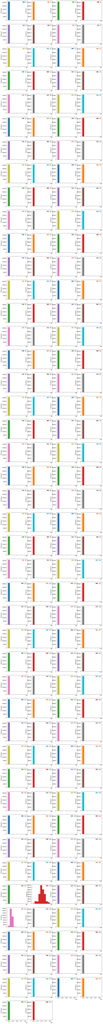

```python
# Histograms for each attribute
df_features_train.plot(kind='hist', subplots=True, layout=(display_rows, display_columns))
plt.show()
```

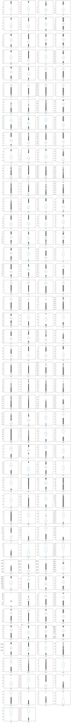

```python
# Box and Whisker plot for each attribute
df_features_train.plot(kind='box', subplots=True, layout=(display_rows, display_columns))
plt.show()
```

```python
# # Correlation matrix
# fig = plt.figure(figsize=(20,20))
# ax = fig.add_subplot(111)
# correlations = df_features_train.corr(method='pearson')
# cax = ax.matshow(correlations, vmin=-1, vmax=1)
# fig.colorbar(cax)
# plt.show()
```

```python
if NOTIFY_STATUS: status_notify("Task 2 - Summarize and Visualize Data completed! " + datetime.now().strftime('%a %B %d, %Y %I:%M:%S %p'))
```

## Task 3 - Pre-process Data

```python
if NOTIFY_STATUS: status_notify("Task 3 - Pre-process Data has begun! " + datetime.now().strftime('%a %B %d, %Y %I:%M:%S %p'))
```

### 3.a) Feature Scaling

```python
# Compose pipeline for the numerical and categorical features (Block #1 of 2)
numeric_columns = df_features_train.select_dtypes(include=['int64','float64']).columns
numeric_transformer = Pipeline(steps=[
    ('imputer', impute.SimpleImputer(strategy="constant", fill_value=0)),
    ('scaler', preprocessing.MinMaxScaler())
])
categorical_columns = df_features_train.select_dtypes(include=['object','bool','category']).columns
categorical_transformer = Pipeline(steps=[
    ('imputer', impute.SimpleImputer(strategy='constant', fill_value='UKNOWN')),
    ('onehot', preprocessing.OneHotEncoder(sparse=False, handle_unknown='ignore'))
])

print("Number of numerical columns:", len(numeric_columns))
print("Number of categorical columns:", len(categorical_columns))
print("Total number of columns in the feature dataframe:", df_features_train.shape[1])
```

```
Number of numerical columns: 174
Number of categorical columns: 0
Total number of columns in the feature dataframe: 174
```

```python
# Compose pipeline for the numerical and categorical features (Block #2 of 2)
preprocessor = compose.ColumnTransformer(transformers=[
    ('num', numeric_transformer, numeric_columns),
    ('cat', categorical_transformer, categorical_columns)
], remainder='passthrough')

# Display the shapes of the training dataset for final inspection
array_features_train = preprocessor.fit_transform(df_features_train)
print("Transformed features from df_features_train.shape: {} to array_features_train.shape: {}".format(df_features_train.shape, array_features_train.shape))
```

```
Transformed features from df_features_train.shape: (260667, 174) to array_features_train.shape: (260667, 174)
```

### 3.b) Training Data Balancing

```python
# Not applicable for this iteration of the project
```

### 3.c) Feature Selection

```python
# Not applicable for this iteration of the project
```

### 3.d) Display the Final Datasets for Model-Building

```python
# Finalize the training dataset for the modeling activities
# array_features_train = df_features_train.to_numpy()
# array_target_train = df_target_train.ravel()
label_encoder = preprocessing.LabelEncoder()
array_target_train = label_encoder.fit_transform(df_target_train)
print("array_features_train.shape: {} array_target_train.shape: {}".format(array_features_train.shape, array_target_train.shape))
```

```
array_features_train.shape: (260667, 174) array_target_train.shape: (260667,)
```

```python
if NOTIFY_STATUS: status_notify("Task 3 - Pre-process Data completed! " + datetime.now().strftime('%a %B %d, %Y %I:%M:%S %p'))
```

## Task 4 - Train and Tune Models

```python
if NOTIFY_STATUS: status_notify("Task 4 - Train and Tune Models has begun! " + datetime.now().strftime('%a %B %d, %Y %I:%M:%S %p'))
```

### 4.a) Set test options and evaluation metric

```python
# Set up Algorithms Spot-Checking Array
start_time_training = datetime.now()
train_models = []
train_results = []
train_model_names = []
train_metrics = []
```

```python
# train_models = [('XGB', XGBClassifier(random_state=RNG_SEED, n_jobs=N_JOBS, objective='multi:softprob', use_label_encoder=False, eval_metric='mlogloss'))]
train_models = [('XGB', XGBClassifier(random_state=RNG_SEED, n_jobs=N_JOBS, objective='multi:softprob', use_label_encoder=False, eval_metric='mlogloss', tree_method='gpu_hist'))]
```

```python
# Generate model in turn
for name, model in train_models:
    if NOTIFY_STATUS: status_notify("Algorithm "+name+" modeling has begun! " + datetime.now().strftime('%a %B %d, %Y %I:%M:%S %p'))
    start_time_module = datetime.now()
    kfold = StratifiedKFold(n_splits=N_FOLDS, shuffle=True, random_state=RNG_SEED)
    cv_results = cross_val_score(model, array_features_train, array_target_train, cv=kfold, scoring=SCORING_METRIC, n_jobs=N_JOBS, verbose=1)
    train_results.append(cv_results)
    train_model_names.append(name)
    train_metrics.append(cv_results.mean())
    print("%s: %f (%f)" % (name, cv_results.mean(), cv_results.std()))
    print(model)
    print ('Model training time:', (datetime.now() - start_time_module), '\n')
    if NOTIFY_STATUS: status_notify("Algorithm "+name+" modeling completed! " + datetime.now().strftime('%a %B %d, %Y %I:%M:%S %p'))
print ('Average metrics (' + SCORING_METRIC + ') from all models:', np.mean(train_metrics))
print ('Total training time for all models:', (datetime.now() - start_time_training))
```

```
[Parallel(n_jobs=2)]: Using backend LokyBackend with 2 concurrent workers.
```

```
XGB: 0.997783 (0.000181)
XGBClassifier(base_score=None, booster=None, colsample_bylevel=None,
              colsample_bynode=None, colsample_bytree=None,
              enable_categorical=False, eval_metric='mlogloss', gamma=None,
              gpu_id=None, importance_type=None, interaction_constraints=None,
              learning_rate=None, max_delta_step=None, max_depth=None,
              min_child_weight=None, missing=nan, monotone_constraints=None,
              n_estimators=100, n_jobs=2, num_parallel_tree=None,
              objective='multi:softprob', predictor=None, random_state=88,
              reg_alpha=None, reg_lambda=None, scale_pos_weight=None,
              subsample=None, tree_method='gpu_hist', use_label_encoder=False,
              validate_parameters=None, ...)
Model training time: 0:00:44.414381

Average metrics (accuracy) from all models: 0.9977826109275847
Total training time for all models: 0:00:46.411955
```

```
[Parallel(n_jobs=2)]: Done   5 out of   5 | elapsed:   44.3s finished
```

### 4.b) Algorithm Tuning

```python
# Set up the comparison array
tune_results = []
tune_model_names = []
```

```python
# Tuning XGBoost n_estimators, max_depth, and min_child_weight parameters
start_time_Module = datetime.now()
if NOTIFY_STATUS: status_notify("Algorithm tuning iteration #1 has begun! " + datetime.now().strftime('%a %B %d, %Y %I:%M:%S %p'))

# tune_model1 = XGBClassifier(random_state=RNG_SEED, n_jobs=N_JOBS, objective='multi:softprob', use_label_encoder=False, eval_metric='mlogloss')
tune_model1 = XGBClassifier(random_state=RNG_SEED, n_jobs=N_JOBS, objective='multi:softprob', use_label_encoder=False, eval_metric='mlogloss', tree_method='gpu_hist')
tune_model_names.append('XGB_1')
paramGrid1 = dict(n_estimators=np.array([100, 300, 500]),
                  max_depth=np.array([3, 6, 9]),
                  min_child_weight=np.array([1, 2, 3]))

kfold = StratifiedKFold(n_splits=N_FOLDS, shuffle=True, random_state=RNG_SEED)
grid1 = GridSearchCV(estimator=tune_model1, param_grid=paramGrid1, scoring=SCORING_METRIC, cv=kfold, n_jobs=N_JOBS, verbose=1)
grid_result1 = grid1.fit(array_features_train, array_target_train)

print("Best: %f using %s" % (grid_result1.best_score_, grid_result1.best_params_))
tune_results.append(grid_result1.cv_results_['mean_test_score'])
means = grid_result1.cv_results_['mean_test_score']
stds = grid_result1.cv_results_['std_test_score']
params = grid_result1.cv_results_['params']
for mean, stdev, param in zip(means, stds, params):
    print("%f (%f) with: %r" % (mean, stdev, param))
print ('Model training time:', (datetime.now() - start_time_Module))
if NOTIFY_STATUS: status_notify("Algorithm tuning iteration #1 completed! " + datetime.now().strftime('%a %B %d, %Y %I:%M:%S %p'))
```

```
Fitting 5 folds for each of 27 candidates, totalling 135 fits
Best: 0.998105 using {'max_depth': 6, 'min_child_weight': 1, 'n_estimators': 500}
0.995765 (0.000098) with: {'max_depth': 3, 'min_child_weight': 1, 'n_estimators': 100}
0.997737 (0.000106) with: {'max_depth': 3, 'min_child_weight': 1, 'n_estimators': 300}
0.998051 (0.000125) with: {'max_depth': 3, 'min_child_weight': 1, 'n_estimators': 500}
0.995646 (0.000246) with: {'max_depth': 3, 'min_child_weight': 2, 'n_estimators': 100}
0.997683 (0.000101) with: {'max_depth': 3, 'min_child_weight': 2, 'n_estimators': 300}
0.997951 (0.000129) with: {'max_depth': 3, 'min_child_weight': 2, 'n_estimators': 500}
0.995673 (0.000248) with: {'max_depth': 3, 'min_child_weight': 3, 'n_estimators': 100}
0.997598 (0.000109) with: {'max_depth': 3, 'min_child_weight': 3, 'n_estimators': 300}
0.997990 (0.000123) with: {'max_depth': 3, 'min_child_weight': 3, 'n_estimators': 500}
0.997783 (0.000181) with: {'max_depth': 6, 'min_child_weight': 1, 'n_estimators': 100}
0.998028 (0.000211) with: {'max_depth': 6, 'min_child_weight': 1, 'n_estimators': 300}
0.998105 (0.000215) with: {'max_depth': 6, 'min_child_weight': 1, 'n_estimators': 500}
0.997691 (0.000175) with: {'max_depth': 6, 'min_child_weight': 2, 'n_estimators': 100}
0.997971 (0.000149) with: {'max_depth': 6, 'min_child_weight': 2, 'n_estimators': 300}
0.998055 (0.000149) with: {'max_depth': 6, 'min_child_weight': 2, 'n_estimators': 500}
0.997629 (0.000124) with: {'max_depth': 6, 'min_child_weight': 3, 'n_estimators': 100}
0.997932 (0.000172) with: {'max_depth': 6, 'min_child_weight': 3, 'n_estimators': 300}
0.997974 (0.000174) with: {'max_depth': 6, 'min_child_weight': 3, 'n_estimators': 500}
0.997767 (0.000147) with: {'max_depth': 9, 'min_child_weight': 1, 'n_estimators': 100}
0.997917 (0.000153) with: {'max_depth': 9, 'min_child_weight': 1, 'n_estimators': 300}
0.997994 (0.000129) with: {'max_depth': 9, 'min_child_weight': 1, 'n_estimators': 500}
0.997717 (0.000098) with: {'max_depth': 9, 'min_child_weight': 2, 'n_estimators': 100}
0.997875 (0.000148) with: {'max_depth': 9, 'min_child_weight': 2, 'n_estimators': 300}
0.997909 (0.000178) with: {'max_depth': 9, 'min_child_weight': 2, 'n_estimators': 500}
0.997691 (0.000130) with: {'max_depth': 9, 'min_child_weight': 3, 'n_estimators': 100}
0.997886 (0.000130) with: {'max_depth': 9, 'min_child_weight': 3, 'n_estimators': 300}
0.997894 (0.000098) with: {'max_depth': 9, 'min_child_weight': 3, 'n_estimators': 500}
Model training time: 0:36:30.909571
```

```python
BEST_MAX_DEPTH = grid_result1.best_params_['max_depth']
BEST_MIN_CHILD_WEIGHT = grid_result1.best_params_['min_child_weight']
BEST_N_ESTIMATORS = grid_result1.best_params_['n_estimators']
print('Best max_depth parameter:', BEST_MAX_DEPTH)
print('Best min_child_weight parameter:', BEST_MIN_CHILD_WEIGHT)
print('Best n_estimators parameter:', BEST_N_ESTIMATORS)
```

```
Best max_depth parameter: 6
Best min_child_weight parameter: 1
Best n_estimators parameter: 500
```

```python
# Tuning XGBoost subsample and colsample_bytree parameters
start_time_Module = datetime.now()
if NOTIFY_STATUS: status_notify("Algorithm tuning iteration #2 has begun! " + datetime.now().strftime('%a %B %d, %Y %I:%M:%S %p'))

# tune_model2 = XGBClassifier(n_estimators=BEST_N_ESTIMATORS, max_depth=BEST_MAX_DEPTH, min_child_weight=BEST_MIN_CHILD_WEIGHT,
#                             random_state=RNG_SEED, n_jobs=N_JOBS, objective='multi:softprob', use_label_encoder=False, eval_metric='mlogloss')
tune_model2 = XGBClassifier(n_estimators=BEST_N_ESTIMATORS, max_depth=BEST_MAX_DEPTH, min_child_weight=BEST_MIN_CHILD_WEIGHT,
                            random_state=RNG_SEED, n_jobs=N_JOBS, objective='multi:softprob', use_label_encoder=False, eval_metric='mlogloss', tree_method='gpu_hist')
tune_model_names.append('XGB_2')
paramGrid2 = dict(subsample=np.array([0.7, 0.8, 0.9, 1.0]),
                  colsample_bytree=np.array([0.7, 0.8, 0.9, 1.0]))

kfold = StratifiedKFold(n_splits=N_FOLDS, shuffle=True, random_state=RNG_SEED)
grid2 = GridSearchCV(estimator=tune_model2, param_grid=paramGrid2, scoring=SCORING_METRIC, cv=kfold, n_jobs=N_JOBS, verbose=1)
grid_result2 = grid2.fit(array_features_train, array_target_train)

print("Best: %f using %s" % (grid_result2.best_score_, grid_result2.best_params_))
tune_results.append(grid_result2.cv_results_['mean_test_score'])
means = grid_result2.cv_results_['mean_test_score']
stds = grid_result2.cv_results_['std_test_score']
params = grid_result2.cv_results_['params']
for mean, stdev, param in zip(means, stds, params):
    print("%f (%f) with: %r" % (mean, stdev, param))
print ('Model training time:',(datetime.now() - start_time_Module))
if NOTIFY_STATUS: status_notify("Algorithm tuning iteration #2 completed! " + datetime.now().strftime('%a %B %d, %Y %I:%M:%S %p'))
```

```
Fitting 5 folds for each of 16 candidates, totalling 80 fits
Best: 0.998239 using {'colsample_bytree': 0.7, 'subsample': 0.9}
0.998105 (0.000151) with: {'colsample_bytree': 0.7, 'subsample': 0.7}
0.998155 (0.000188) with: {'colsample_bytree': 0.7, 'subsample': 0.8}
0.998239 (0.000099) with: {'colsample_bytree': 0.7, 'subsample': 0.9}
0.998155 (0.000113) with: {'colsample_bytree': 0.7, 'subsample': 1.0}
0.998113 (0.000143) with: {'colsample_bytree': 0.8, 'subsample': 0.7}
0.998124 (0.000136) with: {'colsample_bytree': 0.8, 'subsample': 0.8}
0.998178 (0.000120) with: {'colsample_bytree': 0.8, 'subsample': 0.9}
0.998109 (0.000102) with: {'colsample_bytree': 0.8, 'subsample': 1.0}
0.998105 (0.000165) with: {'colsample_bytree': 0.9, 'subsample': 0.7}
0.998109 (0.000148) with: {'colsample_bytree': 0.9, 'subsample': 0.8}
0.998159 (0.000217) with: {'colsample_bytree': 0.9, 'subsample': 0.9}
0.998151 (0.000114) with: {'colsample_bytree': 0.9, 'subsample': 1.0}
0.998082 (0.000133) with: {'colsample_bytree': 1.0, 'subsample': 0.7}
0.997990 (0.000152) with: {'colsample_bytree': 1.0, 'subsample': 0.8}
0.998143 (0.000148) with: {'colsample_bytree': 1.0, 'subsample': 0.9}
0.998105 (0.000215) with: {'colsample_bytree': 1.0, 'subsample': 1.0}
Model training time: 0:35:22.308952
```

```python
BEST_COLSAMPLE_BYTREE = grid_result2.best_params_['colsample_bytree']
BEST_SUBSAMPLE = grid_result2.best_params_['subsample']
print('Best colsample_bytree parameter:', BEST_COLSAMPLE_BYTREE)
print('Best subsample parameter:', BEST_SUBSAMPLE)
```

```
Best colsample_bytree parameter: 0.7
Best subsample parameter: 0.9
```

### 4.c) Compare Algorithms After Tuning

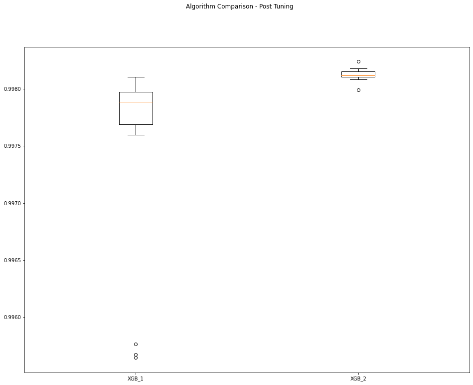

```python
fig = plt.figure(figsize=(16,12))
fig.suptitle('Algorithm Comparison - Post Tuning')
ax = fig.add_subplot(111)
plt.boxplot(tune_results)
ax.set_xticklabels(tune_model_names)
plt.show()
```

```python
if NOTIFY_STATUS: status_notify("Task 4 - Train and Tune Models completed! " + datetime.now().strftime('%a %B %d, %Y %I:%M:%S %p'))
```

## Task 5 - Finalize Model and Make Predictions

```python
if NOTIFY_STATUS: status_notify("Task 5 - Finalize Model and Make Predictions has begun! " + datetime.now().strftime('%a %B %d, %Y %I:%M:%S %p'))
```

### 6.a) Train the Final Model

```python
# final_model = XGBClassifier(n_estimators=BEST_N_ESTIMATORS, max_depth=BEST_MAX_DEPTH, min_child_weight=BEST_MIN_CHILD_WEIGHT,
#                             colsample_bytree=BEST_COLSAMPLE_BYTREE, subsample=BEST_SUBSAMPLE,
#                             random_state=RNG_SEED, n_jobs=N_JOBS, objective='multi:softprob', use_label_encoder=False, eval_metric='mlogloss')
final_model = XGBClassifier(n_estimators=BEST_N_ESTIMATORS, max_depth=BEST_MAX_DEPTH, min_child_weight=BEST_MIN_CHILD_WEIGHT,
                            colsample_bytree=BEST_COLSAMPLE_BYTREE, subsample=BEST_SUBSAMPLE,
                            random_state=RNG_SEED, n_jobs=N_JOBS, objective='multi:softprob', use_label_encoder=False, eval_metric='mlogloss', tree_method='gpu_hist')
final_model.fit(array_features_train, array_target_train)
print(final_model)
```

```
XGBClassifier(base_score=0.5, booster='gbtree', colsample_bylevel=1,
              colsample_bynode=1, colsample_bytree=0.7,
              enable_categorical=False, eval_metric='mlogloss', gamma=0,
              gpu_id=0, importance_type=None, interaction_constraints='',
              learning_rate=0.300000012, max_delta_step=0, max_depth=6,
              min_child_weight=1, missing=nan, monotone_constraints='()',
              n_estimators=500, n_jobs=2, num_parallel_tree=1,
              objective='multi:softprob', predictor='auto', random_state=88,
              reg_alpha=0, reg_lambda=1, scale_pos_weight=None, subsample=0.9,
              tree_method='gpu_hist', use_label_encoder=False,
              validate_parameters=1, ...)
```

### 6.b) Load Test Dataset and Make Predictions

```python
# Finalize the test dataset for the modeling testing
array_features_test = preprocessor.transform(df_features_test)
# array_target_test = df_target_test.ravel()
array_target_test = label_encoder.transform(df_target_test)
print("array_features_test.shape: {} array_target_test.shape: {}".format(array_features_test.shape, array_target_test.shape))
```

```
array_features_test.shape: (65167, 174) array_target_test.shape: (65167,)
```

```python
# Make batched predictions
# test_predictions = label_encoder.inverse_transform(final_model.predict(array_features_test))
test_predictions = final_model.predict(array_features_test)
print(test_predictions)
```

```
[0 0 3 ... 2 3 0]
```

```python
print('Accuracy Score:', accuracy_score(array_target_test, test_predictions), '\n')
print(confusion_matrix(array_target_test, test_predictions), '\n')
print(classification_report(array_target_test, test_predictions))
```

```
Accuracy Score: 0.9982199579541793

[[ 7867     0     3     3     2     2     5]
 [    0   729     0     4     0     0     0]
 [    0     0 14978     1     1     2     0]
 [    3     0     3 14790     8     4     0]
 [    1     0     1    13  9405    24     3]
 [    1     0     3     3    20 17042     0]
 [    2     0     0     0     0     4   240]]

              precision    recall  f1-score   support

           0       1.00      1.00      1.00      7882
           1       1.00      0.99      1.00       733
           2       1.00      1.00      1.00     14982
           3       1.00      1.00      1.00     14808
           4       1.00      1.00      1.00      9447
           5       1.00      1.00      1.00     17069
           6       0.97      0.98      0.97       246

    accuracy                           1.00     65167
   macro avg       0.99      0.99      0.99     65167
weighted avg       1.00      1.00      1.00     65167
```

```python
if NOTIFY_STATUS: status_notify("Task 5 - Finalize Model and Make Predictions completed! " + datetime.now().strftime('%a %B %d, %Y %I:%M:%S %p'))
```

```python
print ('Total time for the script:',(datetime.now() - START_TIME_SCRIPT))
```

```
Total time for the script: 1:20:17.359417
```